# skLearn

```python
import pandas as pd
import numpy as np
df = pd.read_csv("Auto.csv")
print(df.head())
print("Size {}".format(df.size))
print("Shape {}".format(df.shape))
print("nDim {}".format(df.ndim))
```

```
    mpg  cylinders  displacement  horsepower  weight  acceleration  year
0  18.0          8         307.0         130    3504          12.0  70.0  \
1  15.0          8         350.0         165    3693          11.5  70.0
2  18.0          8         318.0         150    3436          11.0  70.0
3  16.0          8         304.0         150    3433          12.0  70.0
4  17.0          8         302.0         140    3449           NaN  70.0

   origin                       name
0       1  chevrolet chevelle malibu
1       1          buick skylark 320
2       1         plymouth satellite
3       1              amc rebel sst
4       1                ford torino
Size 3528
Shape (392, 9)
nDim 2
```

```python
df['mpg'].describe()
```

```
count    392.000000
mean      23.445918
std        7.805007
min        9.000000
25%       17.000000
50%       22.750000
75%       29.000000
max       46.600000
Name: mpg, dtype: float64
```

```python
print(df.dtypes)
df['cylinders'] = df['cylinders'].astype('category')
df['cylinders_codes'] = df['cylinders'].cat.codes
df['origin'] = df['origin'].astype('category')
print(df.dtypes)
```

```
mpg             float64
cylinders         int64
displacement    float64
horsepower        int64
weight            int64
acceleration    float64
year            float64
origin            int64
name             object
dtype: object
mpg                 float64
cylinders          category
displacement        float64
horsepower            int64
weight                int64
acceleration        float64
year                float64
origin             category
name                 object
cylinders_codes        int8
dtype: object
```

```python
df = df.dropna()
print("Shape {}".format(df.shape))
```

```
Shape (389, 10)
```

```python
df['mpg_high'] = df.apply(lambda row: 1 if row['mpg'] > df['mpg'].mean() else 0, axis=1)
df = df.drop(columns=['mpg','name'])
print(df.head())
```

```
  cylinders  displacement  horsepower  weight  acceleration  year origin
0         8         307.0         130    3504          12.0  70.0      1  \
1         8         350.0         165    3693          11.5  70.0      1
2         8         318.0         150    3436          11.0  70.0      1
3         8         304.0         150    3433          12.0  70.0      1
6         8         454.0         220    4354           9.0  70.0      1

   cylinders_codes  mpg_high
0                4         0
1                4         0
2                4         0
3                4         0
6                4         0
```

6. Graphs Data Exploration

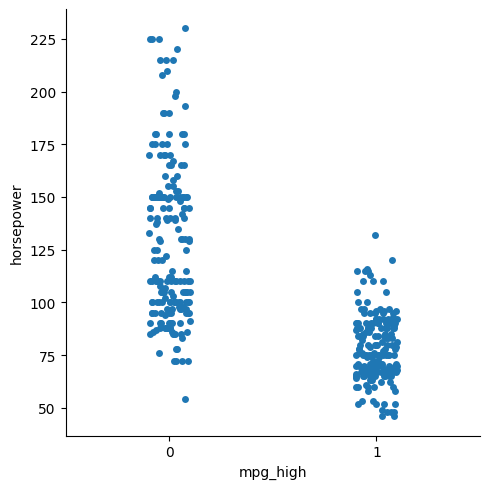

```python
import seaborn as sb
sb.catplot(data=df, x="mpg_high", y="horsepower")
```

This graph shows that vehicles that have a high mpg tend to have a lower horse power.

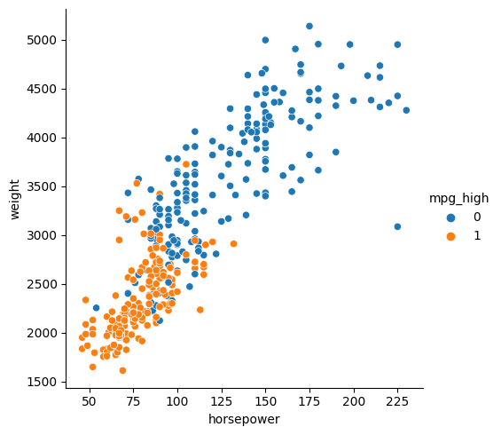

```python
sb.relplot(data=df, x="horsepower", y="weight",hue="mpg_high")
```

This graph shows that weight and horse power are good predictors of mpg_high. Vehicles that have a high mpg tend to be lighter and have less horsepower.

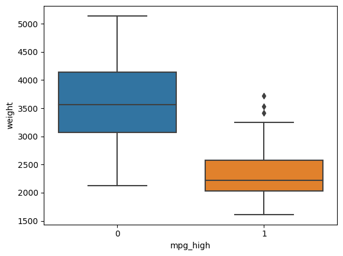

```python
sb.boxplot(data=df, x="mpg_high", y="weight")
```

This graph further shows the correlation between a low weight and a high mpg.

7. Train/Test Split

```python
import sklearn.model_selection as skms
train,test,train_label,test_label = skms.train_test_split(df.drop(['mpg_high'], axis=1), df['mpg_high'], test_size=0.2, random_state=1234)
print("Train Shape {}".format(train.shape))
print("Test Shape {}".format(test.shape))
```

```
Train Shape (311, 8)
Test Shape (78, 8)
```

8. Logistic Regression

```python
import sklearn.linear_model as sklm
import sklearn.metrics as skm
logreg = sklm.LogisticRegression(max_iter=200, solver='lbfgs', random_state=1234)
logreg.fit(train, train_label)
logPred = logreg.predict(test)
logAcc = logreg.score(test, test_label)
print(skm.classification_report(test_label,logPred))
print(f"Logistic Regression Accuracy: {logAcc}")
```

```
              precision    recall  f1-score   support

           0       0.98      0.82      0.89        50
           1       0.75      0.96      0.84        28

    accuracy                           0.87        78
   macro avg       0.86      0.89      0.87        78
weighted avg       0.89      0.87      0.87        78

Logistic Regression Accuracy: 0.8717948717948718
```

9. Decision Tree

```python
import sklearn.tree as skt
tree = skt.DecisionTreeClassifier(random_state=1234)
tree.fit(train, train_label)
treePred = tree.predict(test)
treeAcc = skm.accuracy_score(test_label, treePred)
print(skm.classification_report(test_label, treePred))
print(f"Decision Tree Accuracy: {treeAcc}")
print(skt.export_text(tree, feature_names=['cylinders', 'displacement', 'horsepower', 'weight',' acceleration',' year', 'origin', 'cylinder_codes']))
```

```
              precision    recall  f1-score   support

           0       0.90      0.90      0.90        50
           1       0.82      0.82      0.82        28

    accuracy                           0.87        78
   macro avg       0.86      0.86      0.86        78
weighted avg       0.87      0.87      0.87        78

Decision Tree Accuracy: 0.8717948717948718
|--- cylinders <= 5.50
|   |--- horsepower <= 101.00
|   |   |---  year <= 75.50
|   |   |   |--- displacement <= 119.50
|   |   |   |   |--- cylinders <= 3.50
|   |   |   |   |   |--- class: 0
|   |   |   |   |--- cylinders >  3.50
|   |   |   |   |   |--- weight <= 2683.00
|   |   |   |   |   |   |--- weight <= 2377.00
|   |   |   |   |   |   |   |--- class: 1
|   |   |   |   |   |   |--- weight >  2377.00
|   |   |   |   |   |   |   |--- weight <= 2385.00
|   |   |   |   |   |   |   |   |--- class: 0
|   |   |   |   |   |   |   |--- weight >  2385.00
|   |   |   |   |   |   |   |   |--- class: 1
|   |   |   |   |   |--- weight >  2683.00
|   |   |   |   |   |   |--- class: 0
|   |   |   |--- displacement >  119.50
|   |   |   |   |---  acceleration <= 17.75
|   |   |   |   |   |--- horsepower <= 81.50
|   |   |   |   |   |   |--- class: 1
|   |   |   |   |   |--- horsepower >  81.50
|   |   |   |   |   |   |--- horsepower <= 89.00
|   |   |   |   |   |   |   |--- class: 0
|   |   |   |   |   |   |--- horsepower >  89.00
|   |   |   |   |   |   |   |---  year <= 73.00
|   |   |   |   |   |   |   |   |--- class: 1
|   |   |   |   |   |   |   |---  year >  73.00
|   |   |   |   |   |   |   |   |--- class: 0
|   |   |   |   |---  acceleration >  17.75
```

[output cut: 37 more lines]

```
|   |   |   |   |   |   |--- class: 1
|   |   |   |   |   |--- weight >  3085.00
|   |   |   |   |   |   |--- class: 0
|   |   |   |   |--- horsepower >  83.00
|   |   |   |   |   |--- class: 0
|   |   |---  acceleration >  21.60
|   |   |   |--- class: 1
|   |---  year >  79.50
|   |   |--- origin <= 1.50
|   |   |   |--- displacement <= 247.00
|   |   |   |   |--- class: 0
|   |   |   |--- displacement >  247.00
|   |   |   |   |--- class: 1
|   |   |--- origin >  1.50
|   |   |   |--- class: 1
```

10. Neural Network

```python
import sklearn.neural_network as sknn
nnModel1 = sknn.MLPClassifier(hidden_layer_sizes=(5,7), max_iter=1000, solver='adam', random_state=1234)
nnModel2 = sknn.MLPClassifier(hidden_layer_sizes=(4,6), max_iter=1000, solver='lbfgs', random_state=1234)
nnModel1.fit(train,train_label)
nnModel2.fit(train,train_label)
nnPred1 = nnModel1.predict(test)
nnPred2 = nnModel2.predict(test)
nnAcc1 = skm.accuracy_score(test_label, nnPred1)
nnAcc2 = skm.accuracy_score(test_label, nnPred2)
print(skm.classification_report(test_label, nnPred1))
print(f"Neural Network 1 Accuracy: {nnAcc1}")
print(skm.classification_report(test_label, nnPred2))
print(f"Neural Network 2 Accuracy: {nnAcc2}")
```

```
              precision    recall  f1-score   support

           0       1.00      0.82      0.90        50
           1       0.76      1.00      0.86        28

    accuracy                           0.88        78
   macro avg       0.88      0.91      0.88        78
weighted avg       0.91      0.88      0.89        78

Neural Network 1 Accuracy: 0.8846153846153846
              precision    recall  f1-score   support

           0       0.98      0.82      0.89        50
           1       0.75      0.96      0.84        28

    accuracy                           0.87        78
   macro avg       0.86      0.89      0.87        78
weighted avg       0.89      0.87      0.87        78

Neural Network 2 Accuracy: 0.8717948717948718
```

These were the best 2 models I was able to make completly without over fitting the data. Interestingly both models perfored very similarly and I think this is due to the size of the data. There are only at most 8 predictors and only so much information that can be fulled from them.

11. Analysis

All algorithms performed very similary. The logistic regression, decision tree and one of the neural networks all got the same over all accuracy and they only differ in their other metrics. The other neural network technically has a higher accuracy but it seems to have only gotten 1 more correct prediction than the other models.

Logistic Regresion P R 0 0.98 0.82  
1 0.75 0.96 Accuracy: 87%

Decision Tree P R 0 0.90 0.90 1 0.82 0.82 Accuracy: 87%

Nerual Network 1 P R 0 1.00 0.82 1 0.76 1.00 Accuracy: 88%

Nerual Network 2 P R 0 0.98 0.82 1 0.75 0.96 Accuracy: 87%

Personally I am more comfortable with Python as even though I dont have much experience using it, it is much much closer to languages I do have experience in than R is. But, once i learned a bit more of how R works it was not bad. I still think I would perfer python though.